# Boston Airbnb Data Analysis

Analyzing the airbnb data for boston and understanding some important business questions...

The dataset contains calendar availability for each of these listings and user reviews on the listings.

## The CRISP-DM Process (Cross Industry Process for Data Mining)

It is a data mining process followed in the industry and contains the following steps:

1. Business Understanding - Understanding important business objectives that we will solve by analyzing the data.
2. Data Understanding - Understading the data available, identifying subsets of required data and understanding quality problems in data.
3. Prepare Data - This includes activities line data cleaning, data wrangling, etc. to prepare final datasets required for analysis.
4. Model Data - This technique use data modeling techniques like neural nets which makes data easier to read and helps with clear analysis and processing.
5. Results - Models made in above steps are tested here and results are examined if they will work properly on training data.
6. Deploy - This include deployment of model on unseen data, and create new mechanisms to deal with new data to find solutions for business objectives.

## Business Understanding

- Which is the most reviewed and rated places to stay in Boston?
- What is the airbnb price variation in the city and find some of the cheapest places to stay in Boston?
- How Airbnb prices have varied over time in last two year in Boston?

```python
# importing libraries required for the analysis

import pandas as pd
import numpy as np
import matplotlib
import matplotlib.pyplot as plt
import seaborn as sns
```

## Data Loading and Exploration

```python
# dataframe input
# these csv files were obtained from kaggle.com

df_listings = pd.read_csv('listings.csv')
df_calendar = pd.read_csv('calendar.csv')
df_reviews = pd.read_csv('reviews.csv')
```

```python
# view the first entries for df_listings dataframe

df_listings.head()
```

|  | id | listing_url | scrape_id | last_scraped | name | summary | space | description | experiences_offered | neighborhood_overview | ... | review_scores_value | requires_license | license | jurisdiction_names | instant_bookable | cancellation_policy | require_guest_profile_picture | require_guest_phone_verification | calculated_host_listings_count | reviews_per_month |
| --- | --- | --- | --- | --- | --- | --- | --- | --- | --- | --- | --- | --- | --- | --- | --- | --- | --- | --- | --- | --- | --- |
| 0 | 12147973 | https://www.airbnb.com/rooms/12147973 | 20160906204935 | 2016-09-07 | Sunny Bungalow in the City | Cozy, sunny, family home. Master bedroom high... | The house has an open and cozy feel at the sam... | Cozy, sunny, family home. Master bedroom high... | none | Roslindale is quiet, convenient and friendly. ... | ... | NaN | f | NaN | NaN | f | moderate | f | f | 1 | NaN |
| 1 | 3075044 | https://www.airbnb.com/rooms/3075044 | 20160906204935 | 2016-09-07 | Charming room in pet friendly apt | Charming and quiet room in a second floor 1910... | Small but cozy and quite room with a full size... | Charming and quiet room in a second floor 1910... | none | The room is in Roslindale, a diverse and prima... | ... | 9.0 | f | NaN | NaN | t | moderate | f | f | 1 | 1.30 |
| 2 | 6976 | https://www.airbnb.com/rooms/6976 | 20160906204935 | 2016-09-07 | Mexican Folk Art Haven in Boston | Come stay with a friendly, middle-aged guy in ... | Come stay with a friendly, middle-aged guy in ... | Come stay with a friendly, middle-aged guy in ... | none | The LOCATION: Roslindale is a safe and diverse... | ... | 10.0 | f | NaN | NaN | f | moderate | t | f | 1 | 0.47 |
| 3 | 1436513 | https://www.airbnb.com/rooms/1436513 | 20160906204935 | 2016-09-07 | Spacious Sunny Bedroom Suite in Historic Home | Come experience the comforts of home away from... | Most places you find in Boston are small howev... | Come experience the comforts of home away from... | none | Roslindale is a lovely little neighborhood loc... | ... | 10.0 | f | NaN | NaN | f | moderate | f | f | 1 | 1.00 |
| 4 | 7651065 | https://www.airbnb.com/rooms/7651065 | 20160906204935 | 2016-09-07 | Come Home to Boston | My comfy, clean and relaxing home is one block... | Clean, attractive, private room, one block fro... | My comfy, clean and relaxing home is one block... | none | I love the proximity to downtown, the neighbor... | ... | 10.0 | f | NaN | NaN | f | flexible | f | f | 1 | 2.25 |

5 rows × 95 columns

```python
# view the first entries for df_calendar dataframe

df_calendar.head()
```

|  | listing_id | date | available | price |
| --- | --- | --- | --- | --- |
| 0 | 12147973 | 2017-09-05 | f | NaN |
| 1 | 12147973 | 2017-09-04 | f | NaN |
| 2 | 12147973 | 2017-09-03 | f | NaN |
| 3 | 12147973 | 2017-09-02 | f | NaN |
| 4 | 12147973 | 2017-09-01 | f | NaN |

```python
# view the first entries for df_reviews dataframe

df_reviews.head()
```

|  | listing_id | id | date | reviewer_id | reviewer_name | comments |
| --- | --- | --- | --- | --- | --- | --- |
| 0 | 1178162 | 4724140 | 2013-05-21 | 4298113 | Olivier | My stay at islam's place was really cool! Good... |
| 1 | 1178162 | 4869189 | 2013-05-29 | 6452964 | Charlotte | Great location for both airport and city - gre... |
| 2 | 1178162 | 5003196 | 2013-06-06 | 6449554 | Sebastian | We really enjoyed our stay at Islams house. Fr... |
| 3 | 1178162 | 5150351 | 2013-06-15 | 2215611 | Marine | The room was nice and clean and so were the co... |
| 4 | 1178162 | 5171140 | 2013-06-16 | 6848427 | Andrew | Great location. Just 5 mins walk from the Airp... |

```python
# viewing the columns in df_listings dataframe

df_listings.columns
```

```
Index(['id', 'listing_url', 'scrape_id', 'last_scraped', 'name', 'summary',
       'space', 'description', 'experiences_offered', 'neighborhood_overview',
       'notes', 'transit', 'access', 'interaction', 'house_rules',
       'thumbnail_url', 'medium_url', 'picture_url', 'xl_picture_url',
       'host_id', 'host_url', 'host_name', 'host_since', 'host_location',
       'host_about', 'host_response_time', 'host_response_rate',
       'host_acceptance_rate', 'host_is_superhost', 'host_thumbnail_url',
       'host_picture_url', 'host_neighbourhood', 'host_listings_count',
       'host_total_listings_count', 'host_verifications',
       'host_has_profile_pic', 'host_identity_verified', 'street',
       'neighbourhood', 'neighbourhood_cleansed',
       'neighbourhood_group_cleansed', 'city', 'state', 'zipcode', 'market',
       'smart_location', 'country_code', 'country', 'latitude', 'longitude',
       'is_location_exact', 'property_type', 'room_type', 'accommodates',
       'bathrooms', 'bedrooms', 'beds', 'bed_type', 'amenities', 'square_feet',
       'price', 'weekly_price', 'monthly_price', 'security_deposit',
       'cleaning_fee', 'guests_included', 'extra_people', 'minimum_nights',
       'maximum_nights', 'calendar_updated', 'has_availability',
       'availability_30', 'availability_60', 'availability_90',
       'availability_365', 'calendar_last_scraped', 'number_of_reviews',
       'first_review', 'last_review', 'review_scores_rating',
       'review_scores_accuracy', 'review_scores_cleanliness',
       'review_scores_checkin', 'review_scores_communication',
       'review_scores_location', 'review_scores_value', 'requires_license',
       'license', 'jurisdiction_names', 'instant_bookable',
       'cancellation_policy', 'require_guest_profile_picture',
       'require_guest_phone_verification', 'calculated_host_listings_count',
       'reviews_per_month'],
      dtype='object')
```

## Data Cleaning and Filtering

```python
# removing '$' and ',' symbols from price column in df_calendar and df_listings dataframes
# converting prices in price columns in df_calendar and df_listings dataframes from str to float
# removing the null values from review_scores_value columns in df_listings dataframe


df_calendar[['price']] = df_calendar[['price']].replace('[\$,]','',regex=True).astype(float)
df_calendar = df_calendar.dropna()

df_listings.price = df_listings.price.str.replace('$', '').str.replace(',', '')
df_listings['price'] = df_listings['price'].astype(float)

df_listings = df_listings.dropna(subset=['review_scores_value'])


df_listings["review_scores_value"].isnull().mean()
df_listings = df_listings[~df_listings["review_scores_value"].isnull()]
```

```python
# filtering data for Boston

df_listings = df_listings[df_listings['city'] == 'Boston']
```

```python
# creating new dataframe with filtered data needed required for this study, removing extra columns

df_listings_filter = df_listings[['id','host_listings_count',
       'host_total_listings_count', 'neighbourhood_cleansed',
       'city', 'zipcode', 'property_type', 'room_type', 'accommodates',
       'bathrooms', 'bedrooms', 'beds', 'bed_type', 'amenities',
       'price', 'number_of_reviews', 'review_scores_cleanliness',
       'review_scores_checkin', 'review_scores_communication',
       'review_scores_location', 'review_scores_value', 'calculated_host_listings_count',
       'reviews_per_month']]
```

```python
# view the first entries for df_listings_filter dataframe

df_listings_filter.head()
```

|  | id | host_listings_count | host_total_listings_count | neighbourhood_cleansed | city | zipcode | property_type | room_type | accommodates | bathrooms | ... | amenities | price | number_of_reviews | review_scores_cleanliness | review_scores_checkin | review_scores_communication | review_scores_location | review_scores_value | calculated_host_listings_count | reviews_per_month |
| --- | --- | --- | --- | --- | --- | --- | --- | --- | --- | --- | --- | --- | --- | --- | --- | --- | --- | --- | --- | --- | --- |
| 1 | 3075044 | 1 | 1 | Roslindale | Boston | 02131 | Apartment | Private room | 2 | 1.0 | ... | {TV,Internet,"Wireless Internet","Air Conditio... | 65.0 | 36 | 9.0 | 10.0 | 10.0 | 9.0 | 9.0 | 1 | 1.30 |
| 2 | 6976 | 1 | 1 | Roslindale | Boston | 02131 | Apartment | Private room | 2 | 1.0 | ... | {TV,"Cable TV","Wireless Internet","Air Condit... | 65.0 | 41 | 9.0 | 10.0 | 10.0 | 9.0 | 10.0 | 1 | 0.47 |
| 3 | 1436513 | 1 | 1 | Roslindale | Boston | NaN | House | Private room | 4 | 1.0 | ... | {TV,Internet,"Wireless Internet","Air Conditio... | 75.0 | 1 | 10.0 | 10.0 | 10.0 | 10.0 | 10.0 | 1 | 1.00 |
| 4 | 7651065 | 1 | 1 | Roslindale | Boston | 02131 | House | Private room | 2 | 1.5 | ... | {Internet,"Wireless Internet","Air Conditionin... | 79.0 | 29 | 10.0 | 10.0 | 10.0 | 9.0 | 10.0 | 1 | 2.25 |
| 5 | 12386020 | 2 | 2 | Roslindale | Boston | 02131 | Condominium | Private room | 2 | 1.0 | ... | {"Cable TV","Wireless Internet","Air Condition... | 75.0 | 8 | 10.0 | 10.0 | 10.0 | 9.0 | 10.0 | 1 | 1.70 |

5 rows × 23 columns

```python
# replacing index of listings dataframe with id column
# replacing index of calendar dataframe with listing_id column
# replacing index of reviews dataframe with listing_id column

df_listings_filter.set_index('id', inplace=True)
df_calendar.set_index('listing_id', inplace=True)
df_reviews.set_index('listing_id', inplace=True)
```

# Question 1. Most Reviewed and Rated place in Boston

Let's check the relationship between number_of_reviews, review_score_value and location columns

## Data Visualization

```python
def plot_func(df, group_by, column, operation, title, x_label, y_label):

    '''
    Function: for plotting bar graphs
    INPUT:
    df: dataframe
    group_by: column you want to group the data by
    column: feature to be ploted against groupby data
    operation: aggregate operation made on column
    title: Title of bar plot
    x_label: x-axis label
    y_label: y-axis label
    OUTPUT: Plot of data
    '''

    df.groupby(group_by)[column].agg(operation).plot.bar(figsize =(10,5),title = title)
    plt.xlabel(x_label)
    plt.ylabel(y_label)
```

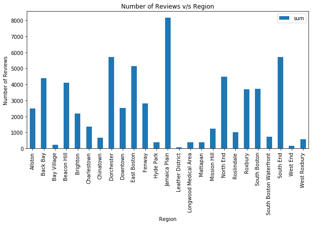

```python
# plotting number of reviews vs for different regions

plot_func(df_listings_filter, 'neighbourhood_cleansed', 'number_of_reviews', ['sum'], 'Number of Reviews v/s Region' , 'Region','Number of Reviews')
```

```python
# total number of reviews for different places in Boston

df_listings_filter.groupby('neighbourhood_cleansed').number_of_reviews.sum()
```

```
neighbourhood_cleansed
Allston                    2491
Back Bay                   4373
Bay Village                 241
Beacon Hill                4095
Brighton                   2167
Charlestown                1358
Chinatown                   669
Dorchester                 5699
Downtown                   2530
East Boston                5150
Fenway                     2806
Hyde Park                   370
Jamaica Plain              8154
Leather District             69
Longwood Medical Area       392
Mattapan                    393
Mission Hill               1237
North End                  4482
Roslindale                 1015
Roxbury                    3698
South Boston               3707
South Boston Waterfront     744
South End                  5710
West End                    156
West Roxbury                572
Name: number_of_reviews, dtype: int64
```

### Analysis

Jamaica Plain is the most reviewed place while Leather District is the least....

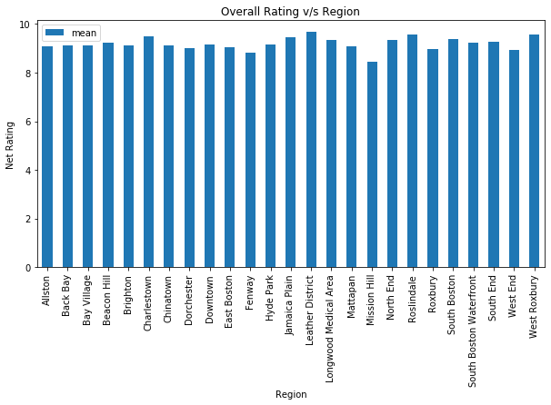

```python
# plotting Average overall rating for all places in Boston
plot_func(df_listings_filter, 'neighbourhood_cleansed', 'review_scores_value', ['mean'], 'Overall Rating v/s Region' , 'Region','Net Rating')
```

```python
# average rating for different places in Boston

df_listings_filter.groupby('neighbourhood_cleansed').review_scores_value.mean()
```

```
neighbourhood_cleansed
Allston                    9.078788
Back Bay                   9.123932
Bay Village                9.125000
Beacon Hill                9.244048
Brighton                   9.119658
Charlestown                9.509434
Chinatown                  9.121951
Dorchester                 9.009524
Downtown                   9.152542
East Boston                9.053030
Fenway                     8.837838
Hyde Park                  9.166667
Jamaica Plain              9.446097
Leather District           9.666667
Longwood Medical Area      9.333333
Mattapan                   9.066667
Mission Hill               8.435484
North End                  9.325000
Roslindale                 9.581395
Roxbury                    8.963964
South Boston               9.384106
South Boston Waterfront    9.224138
South End                  9.263941
West End                   8.923077
West Roxbury               9.560000
Name: review_scores_value, dtype: float64
```

### Analysis

Average rating is highest for Leather District and least for Mission Hill

# Question 2. Price Variation over Boston

We cleaned the price column above in Data Cleaning and Filtering, price is now float. Let's compare these numerical price values with neighbourhood...

## Data Preperation

```python
# creating new dataframe with filtered data needed required for studying price variation, removing extra columns

df_price = df_listings_filter[[ 'neighbourhood_cleansed',
       'city', 'zipcode',
        'property_type', 'room_type', 'accommodates',
       'bathrooms', 'bedrooms', 'beds', 'bed_type', 'amenities',
       'price']]
```

```python
# view the first entries for df_price dataframe

df_price.head()
```

| id | neighbourhood_cleansed | city | zipcode | property_type | room_type | accommodates | bathrooms | bedrooms | beds | bed_type | amenities | price |
| --- | --- | --- | --- | --- | --- | --- | --- | --- | --- | --- | --- | --- |
| 3075044 | Roslindale | Boston | 02131 | Apartment | Private room | 2 | 1.0 | 1.0 | 1.0 | Real Bed | {TV,Internet,"Wireless Internet","Air Conditio... | 65.0 |
| 6976 | Roslindale | Boston | 02131 | Apartment | Private room | 2 | 1.0 | 1.0 | 1.0 | Real Bed | {TV,"Cable TV","Wireless Internet","Air Condit... | 65.0 |
| 1436513 | Roslindale | Boston | NaN | House | Private room | 4 | 1.0 | 1.0 | 2.0 | Real Bed | {TV,Internet,"Wireless Internet","Air Conditio... | 75.0 |
| 7651065 | Roslindale | Boston | 02131 | House | Private room | 2 | 1.5 | 1.0 | 2.0 | Real Bed | {Internet,"Wireless Internet","Air Conditionin... | 79.0 |
| 12386020 | Roslindale | Boston | 02131 | Condominium | Private room | 2 | 1.0 | 1.0 | 1.0 | Real Bed | {"Cable TV","Wireless Internet","Air Condition... | 75.0 |

## Data Visualizations

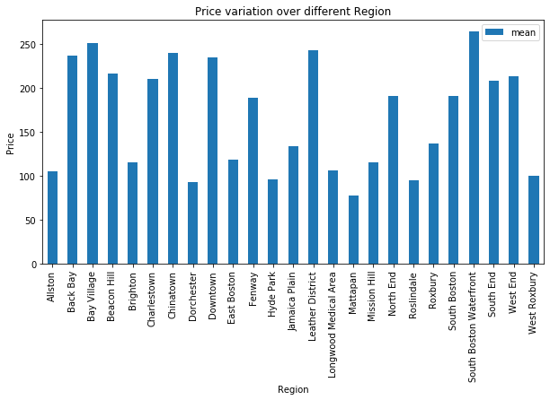

```python
# plotting average price per region

plot_func(df_price, 'neighbourhood_cleansed', 'price', ['mean'], 'Price variation over different Region' , 'Region','Price')
```

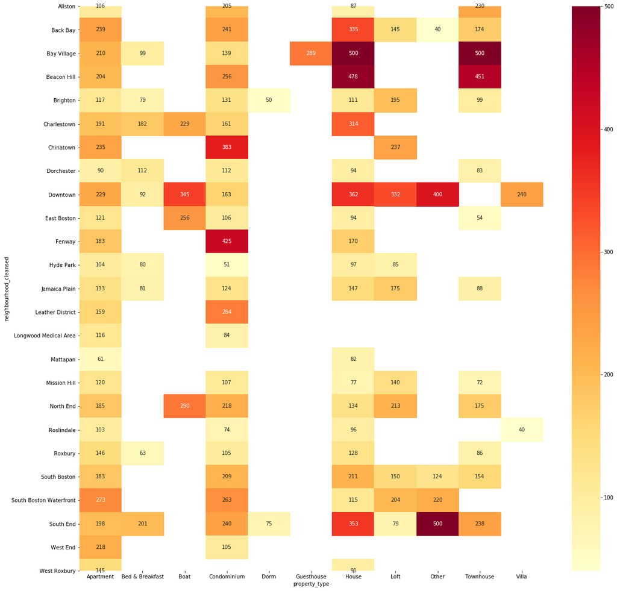

```python
# plotting price variation on the basis of property type in different regions

plt.figure(figsize=(20,20));
sns.heatmap(df_price.groupby(['neighbourhood_cleansed', 'property_type']).price.mean().unstack(),annot=True, fmt=".0f", cmap="YlOrRd");
```

### Analysis

Cheapest - Rent a villa in Roslindale = $40 / night

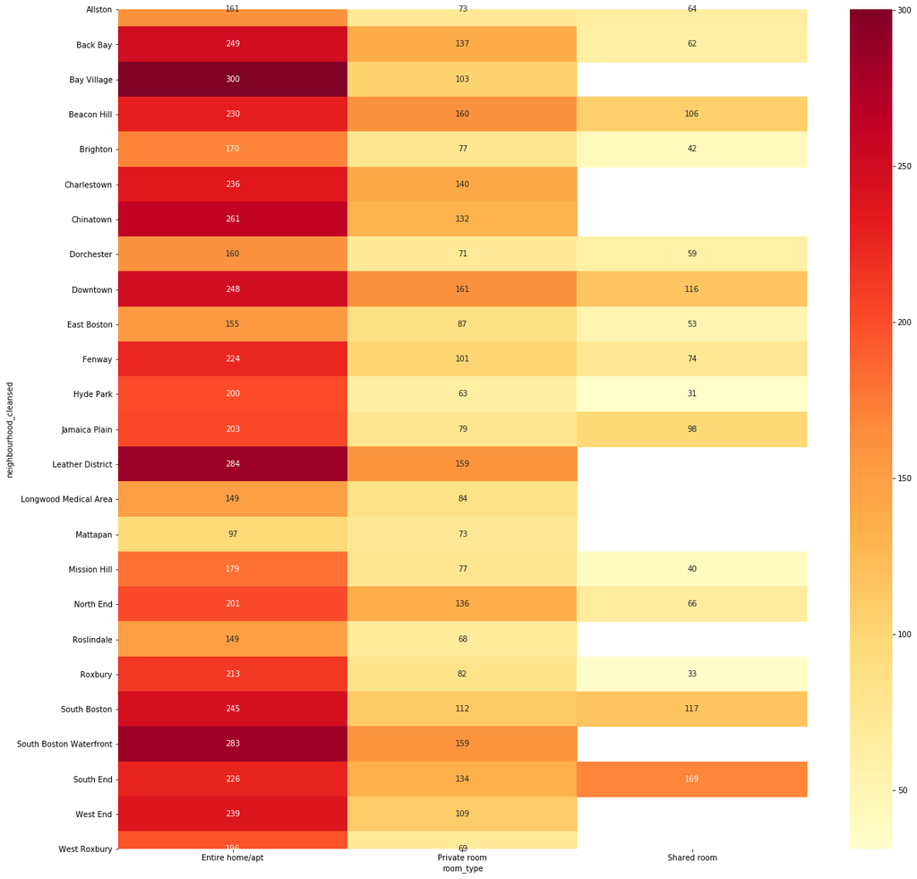

```python
# plotting price variation on the basis of type of room in different regions

plt.figure(figsize=(20,20));
sns.heatmap(df_price.groupby(['neighbourhood_cleansed', 'room_type']).price.mean().unstack(),annot=True, fmt=".0f", cmap="YlOrRd");
```

### Analysis

# Question 3. Price variation over time

Let's see how price column ranks against the dates! We can save money if we plan our itinerary around the cheaper months...

## Data Preperation

```python
# view the first entries for df_calendar dataframe

df_calendar.head()
```

| listing_id | date | available | price |
| --- | --- | --- | --- |
| 3075044 | 2017-08-22 | t | 65.0 |
| 3075044 | 2017-08-21 | t | 65.0 |
| 3075044 | 2017-08-20 | t | 65.0 |
| 3075044 | 2017-08-19 | t | 75.0 |
| 3075044 | 2017-08-18 | t | 75.0 |

```python
# dropping Nan rows from df_calender dataframe

df_calendar = df_calendar.dropna(subset = ['price'])
```

```python
# changing date in df_calendar dataframe from string to datetime type

df_calendar['date'] = pd.to_datetime(df_calendar['date'])
df_calendar.head()
```

| listing_id | date | available | price |
| --- | --- | --- | --- |
| 3075044 | 2017-08-22 | t | 65.0 |
| 3075044 | 2017-08-21 | t | 65.0 |
| 3075044 | 2017-08-20 | t | 65.0 |
| 3075044 | 2017-08-19 | t | 75.0 |
| 3075044 | 2017-08-18 | t | 75.0 |

```python
# creating new columns for date, year and days in df_calendar dataframe

df_calendar['year'] = df_calendar['date'].dt.year
df_calendar['month'] = df_calendar['date'].dt.month
df_calendar['days'] = df_calendar['date'].dt.dayofweek
```

```python
# adding neighbourhood_cleansed column from df_listings_filter dataframe to df_calendar

df_calendar['neighbourhood_cleansed'] = df_listings_filter['neighbourhood_cleansed']
df_calendar['number_of_reviews'] = df_listings_filter['number_of_reviews']
df_calendar.head()
```

| listing_id | date | available | price | year | month | days | neighbourhood_cleansed | number_of_reviews |
| --- | --- | --- | --- | --- | --- | --- | --- | --- |
| 3075044 | 2017-08-22 | t | 65.0 | 2017 | 8 | 1 | Roslindale | 36.0 |
| 3075044 | 2017-08-21 | t | 65.0 | 2017 | 8 | 0 | Roslindale | 36.0 |
| 3075044 | 2017-08-20 | t | 65.0 | 2017 | 8 | 6 | Roslindale | 36.0 |
| 3075044 | 2017-08-19 | t | 75.0 | 2017 | 8 | 5 | Roslindale | 36.0 |
| 3075044 | 2017-08-18 | t | 75.0 | 2017 | 8 | 4 | Roslindale | 36.0 |

## Data Visualization

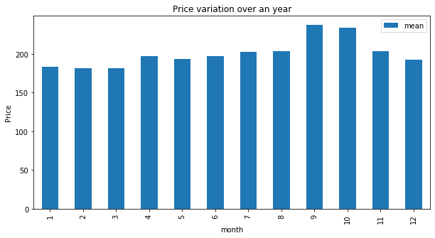

```python
# plotting price variation in Boston over months in an year

plot_func(df_calendar, 'month', 'price', ['mean'], 'Price variation over an year' , 'month','Price')
```

```python
# average airbnb prices over months in Boston

df_calendar.groupby('month').price.mean()
```

```
month
1     182.799671
2     180.961028
3     181.818742
4     197.252890
5     193.712295
6     196.535302
7     202.486309
8     203.330142
9     237.047727
10    233.416248
11    202.924416
12    192.601915
Name: price, dtype: float64
```

### Analysis

September and October has the highest airbnb prices in whole year, while Feburary and March are the cheapest.

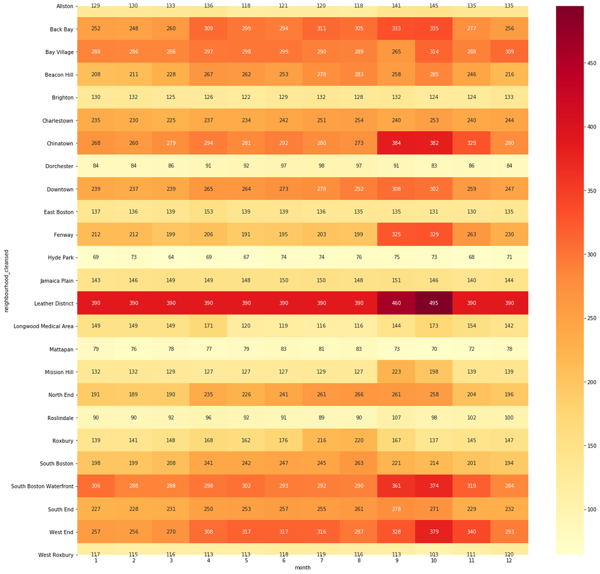

```python
# plotting price variation in different regions of Boston over months in an year


plt.figure(figsize=(20,20));
sns.heatmap(df_calendar.groupby(['neighbourhood_cleansed', 'month']).price.mean().unstack(),annot=True, fmt=".0f", cmap="YlOrRd");
```

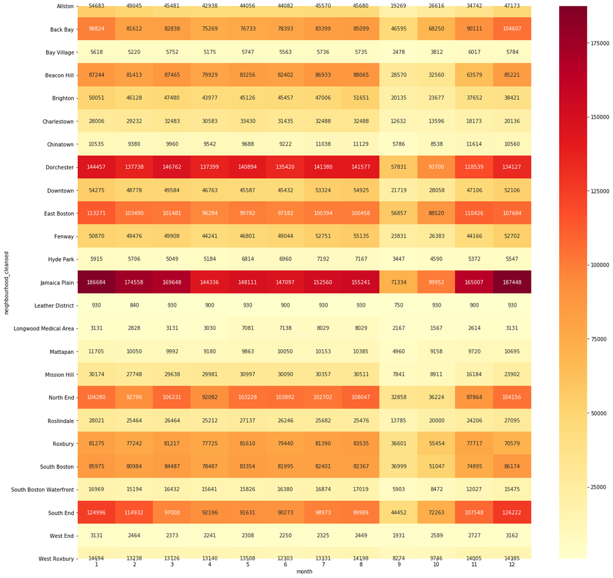

```python
# plotting total number of reviews received over months in different regions of Boston


plt.figure(figsize=(20,20));
sns.heatmap(df_calendar.groupby(['neighbourhood_cleansed', 'month']).number_of_reviews.sum().unstack(),annot=True, fmt=".0f", cmap="YlOrRd");
```

### Analysis

Seems to depend more on location than on month. But we generally get higher reviews in December and January which may be due to increase in visitors because of winter break, chrishmas and new year.

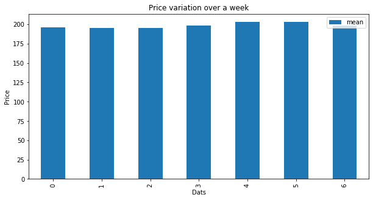

```python
# plotting price variation over a week

plot_func(df_calendar, 'days', 'price', ['mean'], 'Price variation over a week' , 'Dats','Price')
```

```python
# average airbnb prices on different days in a week in Boston


df_calendar.groupby('days').price.mean()
```

```
days
0    195.809561
1    195.173842
2    195.418228
3    198.073112
4    203.121167
5    203.408387
6    198.219764
Name: price, dtype: float64
```

### Analysis

Friday and Saturdays are somewhat costlier than other days in a week...